# PML Course Project

Nick Imrei

Thursday, August 21, 2014

## Machine Learning: Analysis and Prediction of the Weight Lifting Exercises Dataset

### Executive Summary

Can we predict from exercise data whether the exercise in question was performed properly?

This study uses a variety of devices such as *Jawbone Up*, *Nike FuelBand* and *Fitbit* to capture positional/displacement data. Whilst performing a variety of barbell exercises, participants were asked to perform the excercise both correctly and incorrectly.

The original study performed on this dataset can be found [here](http://groupware.les.inf.puc-rio.br/har)

## Data cleansing and exploratory analysis

First, load any libraries we need. These include:

```r
suppressMessages(library(caret))
suppressMessages(library(doParallel))
```

```r
suppressMessages(library(corrplot))
suppressMessages(library(rattle))
registerDoParallel(cores = 4)
set.seed(123)
```

The test and training datasets used for this study can be found at the following locations:

- [Training dataset](https://d396qusza40orc.cloudfront.net/predmachlearn/pml-training.csv)
- [Testing dataset](https://d396qusza40orc.cloudfront.net/predmachlearn/pml-testing.csv)

Both datasets contain features with a number of missing values that came in one of 3 forms:

- Blank entries
- `'#DIV/0!'`
- `'NA'`.

These values are set to `NA` when we read in the training and test sets so that they can be addressed differently, ignored or removed when building our prediction model.

```r
training.filename <- "pml-training.csv"
testing.filename <- "pml-testing.csv"

#download our files if they're not stored locally
if (!file.exists(training.filename)) {
  download.file("https://d396qusza40orc.cloudfront.net/predmachlearn/pml-training.csv", training.filename)
}
if (!file.exists(testing.filename)) {
  download.file("https://d396qusza40orc.cloudfront.net/predmachlearn/pml-testing.csv", testing.filename)
}

#read the training and testing files into their respective dataframes
training <- read.csv(training.filename, na.strings=c("#DIV/0!","NA",""))
testing <- read.csv(testing.filename, na.strings=c("#DIV/0!","NA",""))
```

Each dataset has 160 features (159 + our outcome variable, `classe`). With our `NA` entries now properly identified, columns are made up of mostly (i.e. > 80%) of missing values, and discard them as they’re expected to have little to no impact on the final prediction model.

Additionally, there are other features that can also be dropped from our datasets. These include:

- Unique row identifiers (`X`).
- Repetitions of existing features (e.g. `raw_timestamp_part_1` & `raw_timestamp_part_2` features are repetitions of `cvtd_timestamp`).
- 95% the same value, in which case they’re dropped as noise (e.g. `num_window`, `new_window`).

```r
#have a look which feature are > 80% NA values
column.stats <- colSums(!is.na(training))/nrow(training)
column.filter <- c(names(column.stats[column.stats > .8]))

#remove all repeated timestamp & row identifier features
column.filter <- column.filter[-c(1:7)]

#filter our features by the above criteria
training <- training[,column.filter]

#apply the same feature selection as per training set
testing <- testing[,names(testing) %in% column.filter]
```

After filtering out extraneous features, the training dataset should now have 53 variables made up of 52 predictors and 1 outcome. The correlation between the predictors is now examined, as any variables that are highly correlated could theoretically be replaced with weighted combinations of other predictor variables.

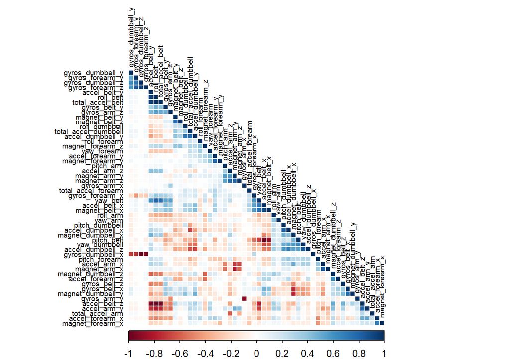

```r
corrplot(cor(training[,-53]), method = "color", type = "lower",order = "hclust",
         tl.cex = 0.6, tl.col=rgb(0,0,0))
```

The above grid shows the correlation between feature pairs in the training dataset. Dark blue squares represent positive correlations and dark red negative correlations. To help determine a set of linearly uncorrelated feature to use as our predictor variables when building our model, we’ll perform a principal components analysis.

### Principal components analysis and machine learning

A principal components analysis is now performed on the prospective predictor variables to help determine which subset of variables account for 99% of the variance of the model. This is done by partitioning the training dataset into (via a 70/30 percent split) into 2 subsets:

1. `training.subset`: To train the model for the principal components analysis & eventually our prediction model.
2. `validation.subset`: set to assess the effectiveness of the the prediction model when the outcomes are known.

```r
#partition the training into training & validation subsets for our pca
training.indexes = createDataPartition(y = training$classe, p = 0.7, list = FALSE)
training.subset <- training[training.indexes,]
validation.subset <- training[-training.indexes,]

#pre process our partitioned data, retaining 99% of the variance of the original data
preproc.training.subset <- preProcess(training.subset[, -53], method = "pca", thresh = 0.99)

#predict our training and validation partitions, using our intended model
training.subset.predict <- predict(preproc.training.subset, training.subset[, -53])
```

**Training the prediction model**

```r
#set our training control object to perform 10-fold cross-validation in parallel
train.control = trainControl(method = "cv", number = 10, allowParallel=T)

#build the random forrest off the our pre-processed dataset, using the cross validation method defined in the train.control object
# model.rf <- train(classe ~ ., data=training.subset, method="rf", preProcess=c("center", "scale"), trControl=train.control, importance=T)
```

```r
# varImpPlot(model.rf$finalModel, sort = T, type = 2, pch = 20, col = 1, cex = .8, mar = c(5.1,4.1,4.1,2.1), main = "Importance of Principal Components")
```

$accuracy = {totalcorrectlyclassified}/{total}$

```r
# validation.subset.predict <- predict(model.rf, validation.subset)
# confusionMatrix(validation.subset$classe, validation.subset.predict)$table
```

Out of sample error is calculated as: $error_{outofsample} = 1 - accuracy$

```r
#
# accuracy <- postResample(validation.subset$classe, validation.subset.predict)[[1]]
# accuracy
#
# out.of.sample.error <- 1-accuracy
# out.of.sample.error
```

```r
# testing.classe.prediction <- predict(model.rf, testing)
# testing.classe.prediction
```